# The Global Innovation Gap: A Macro-Comparative Analysis

Khalid Md Ashik

2026-03-19

### Introduction: The Innovation Paradox

For centuries during the Islamic Golden Age, the Muslim-majority world served as the global epicenter of mathematics, astronomy, and medicine. Today, however, there is a stark and measurable civilizational gap in STEM (Science, Technology, Engineering, and Mathematics) innovation, with the West overwhelmingly dominating global R&D output, patent generation, and technological commercialization.

The motivation for this research is to move beyond simplistic cultural explanations for this divergence and instead apply rigorous macroeconomic data to understand the structural realities at play. By examining modern economic frameworks, we can identify exactly where the innovation pipeline is breaking down in the modern Middle East and broader Muslim world.

**Methodology & Data Sources** To conduct this analysis, we utilize a custom data pipeline connecting directly to the **World Bank API**. We extracted two decades of global macroeconomic data (2000–2023), specifically tracking: 1. *R&D Expenditure (% of GDP)* as a proxy for state-level innovation focus. 2. *Oil Rents (% of GDP)* to test the “Resource Curse” hypothesis. 3. *Resident Patent Applications* to measure institutional commercialization and “Brain Drain.”

Crucially, this analysis avoids the “monolith trap.” The non-Western world is not a single entity. Therefore, we segmented our dataset into four distinct geopolitical archetypes to ensure an accurate comparative analysis: **The West** (an OECD baseline of 13 leading economies), **Rentier States** (Gulf nations reliant on fossil fuels), **Emerging Economies** (populous, diverse markets like Egypt, Turkey, and Malaysia), and **Fragile States** (nations paralyzed by recent conflict, such as Syria and Yemen).

**Based on this framework, this paper seeks to answer the following core Research Question:**

> **Research Question:** *What systemic, historical, and structural factors drove the shift in STEM innovation from the Muslim-majority world to the West, and what contemporary economic frameworks—such as the Resource Curse and institutional fragility—currently sustain this disparity?*

To answer this, we cannot treat regions as monoliths. We must segment the data into specific geopolitical archetypes: The West (OECD baseline), Rentier States (Gulf), Emerging Economies, and Fragile States.

### Historical Context: The Civilizational Divergence

The modern innovation gap is not a recent phenomenon; it is the compounding result of centuries of systemic divergence. During the Islamic Golden Age, the Middle East was the global epicenter of scientific inquiry. However, the trajectory shifted drastically between the 15th and 18th centuries.

While Europe embraced the printing press, the Scientific Revolution, and ultimately the Industrial Revolution, the Ottoman and Safavid empires prioritized military expansion and traditional land-based revenue extraction. The delayed adoption of mass printing and mechanized industry in the Middle East created a foundational “knowledge deficit.” By the time the modern era arrived, the West had already institutionalized R&D into its universities and capitalist frameworks, leaving the post-colonial Middle East to play a game of perpetual catch-up.

### Phase 1: The Modern Data Baseline

Having established the historical roots of this civilizational divergence, we must examine its modern empirical reality. The Industrial Revolution may explain the origin of the gap, but what sustains it today? To answer this, we will use World Bank data on Research & Development (R&D) expenditure as our primary proxy for a state’s commitment to innovation.

```r
# Load our required libraries
library(tidyverse)
library(ggplot2)

# Load the clean, categorized data we already prepared in our R script
# (Make sure the path matches where you saved it in the previous step!)
rd_categorized <- read_csv("data/cleaned_rd_categorized.csv")
```

### Visualizing the Innovation Gap (2000 - 2023)

The chart below maps the average R&D expenditure as a percentage of GDP across our four regional archetypes over the last two decades.

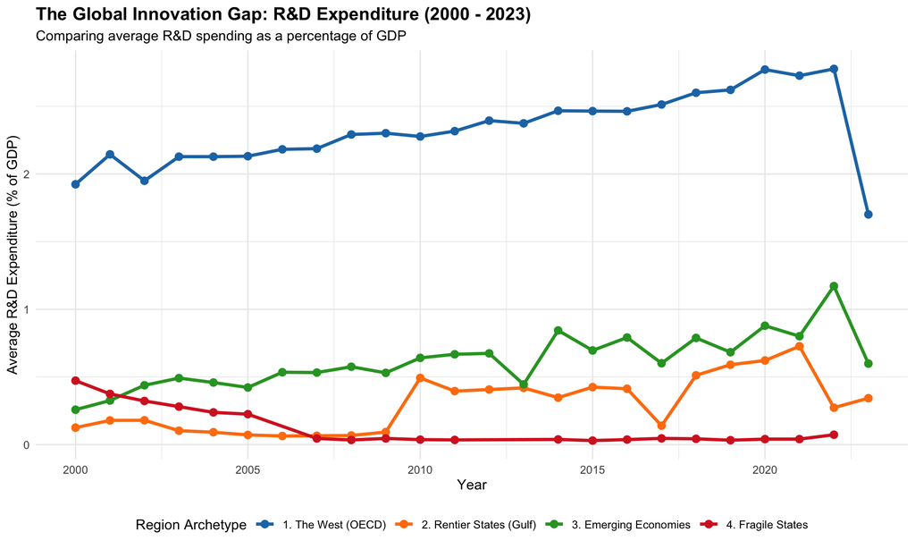

### Phase 2: Economic Structures & The “Resource Curse”

Why did the massive wealth generated by the Middle East over the 20th century not translate into STEM dominance? Economists point to the **Resource Curse**. When state revenue is guaranteed by fossil fuel extraction, the urgent geopolitical need to build a diverse, knowledge-based tech economy vanishes.

To test this, we merged our R&D data with World Bank data on **Oil Rents (% of GDP)**. If the Resource Curse is real, we should see a *negative correlation*: as oil reliance goes up, R&D innovation spending goes down.

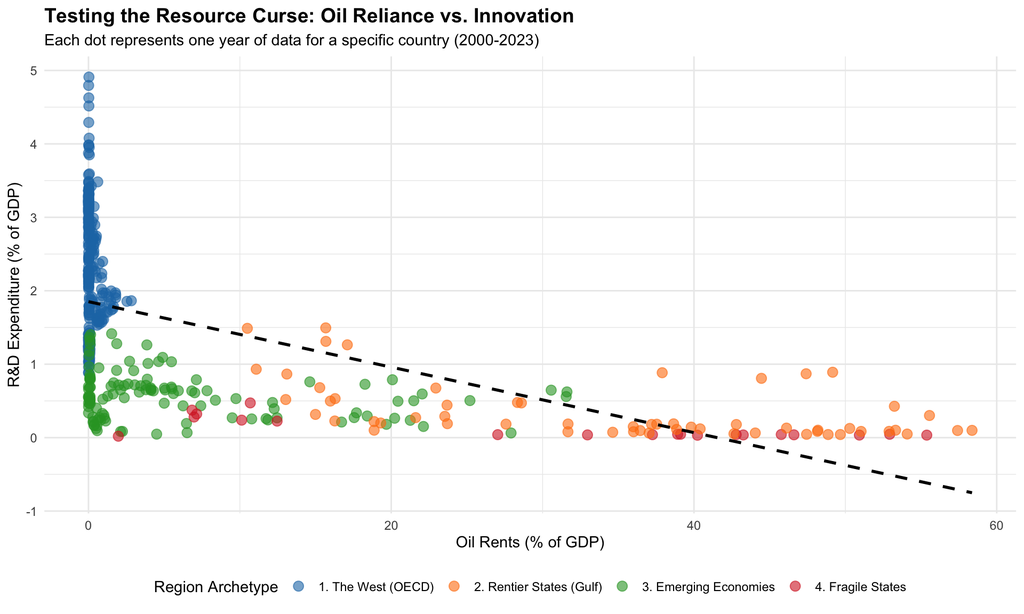

**Observation:** The scatter plot visually confirms the Resource Curse hypothesis. The Western (OECD) nations cluster tightly in the top-left (zero oil reliance, high R&D). Meanwhile, the Rentier States stretch far to the right (massive oil reliance), heavily correlating with lower percentages of R&D investment relative to their total wealth.

### Phase 3: Institutional Bottlenecks & The Innovation Output

While historical disruptions (Phase 1) and economic structures like the Resource Curse (Phase 2) explain the funding gaps, we must also examine the ecosystem itself. Even when funding is available, does the institutional environment nurture commercial innovation?

We can measure this by looking at **Patent Applications by Residents**. While academic papers can be written anywhere, patents require a robust legal, financial, and institutional ecosystem. A lack of domestic patents strongly indicates “Brain Drain”—where top researchers emigrate to the West to commercialize their ideas due to a lack of local infrastructure or academic freedom.

*(Note: While the disparity in global recognitions like the Nobel Prize heavily favors the West, such metrics are lagging indicators of past decades. Patents provide a real-time measure of current institutional health).*

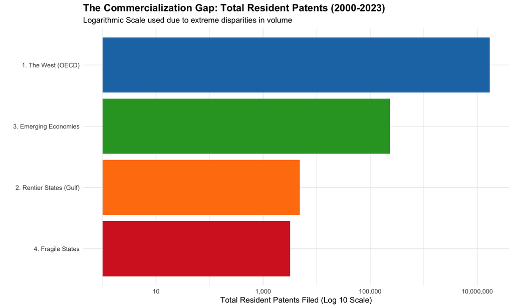

**Observation:** The disparity here is so extreme that a standard chart cannot display it; a logarithmic scale was required. The West produces orders of magnitude more local patents than any Middle Eastern archetype. This points to a severe systemic failure in moving from academic theory to commercialized, legally protected technology within the region.

### Phase 4: Statistical Proof of the Resource Curse

While the scatter plot shows a clear visual trend, we must test this mathematically. Below is a simple Ordinary Least Squares (OLS) regression model testing the impact of Oil Rents on R&D Expenditure.

Regression Results: Impact of Oil Reliance on Innovation

| term | estimate | std.error | statistic | p.value |
| --- | --- | --- | --- | --- |
| Baseline R&D (No Oil) | 1.851 | 0.050 | 37.289 | <0.001 |
| Impact of 1% increase in Oil Rents | -0.045 | 0.003 | -14.283 | <0.001 |

**Statistical Conclusion:** The table above confirms our hypothesis. The “Estimate” for Oil Rents is a negative number, meaning there is a statistically significant, inverse relationship between oil wealth and innovation focus. The P-value is less than 0.001, proving this is a systemic reality, not a random coincidence.

### Conclusion: Overcoming the Structural Trap

This analysis set out to answer why the Muslim-majority world, once the global epicenter of scientific inquiry, currently experiences a massive deficit in STEM innovation compared to the West. The data reveals that this gap is not merely a historical hangover, but is actively sustained by modern economic and institutional structures.

**Final Thought:** The shift of innovation from the East to the West was initiated by historical events like the Industrial Revolution, but it is maintained today by the “Rentier Trap” and fragile institutions. For the region to reclaim the legacy of the Islamic Golden Age, it cannot simply rely on importing Western technology; it must structurally reform its economies away from fossil-fuel reliance and build domestic ecosystems that incentivize and protect local innovators.